# Luisa Maria Diele-Viegas

### Bio

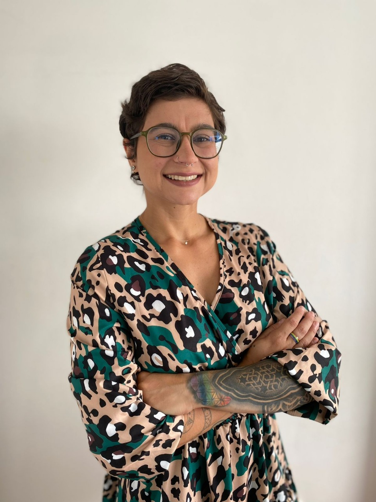

Dra Luisa Maria Diele-Viegas é pesquisadora na Michigan State University, professora permanente do Programa de Pós-Graduação em Ecologia: Teoria, Aplicação e Valores da Universidade Federal da Bahia, e consultora do Programa das Nações Unidas para o Desenvolvimento (PNUD), atuando na implementação da Estratégia e Plano de Ação Nacionais para a Biodiversidade (EPANB) no Brasil. Atualmente é a presidente da Associação Brasileira de Ciência Ecológica e Conservação, presidente do capítulo Brasileiro da Organização para Mulheres na Ciência no Mundo em Desenvolvimento (OWSD), co-fundadora e presidente da Rede Kunhã Asé de Mulheres na Ciência e membra do conselho executivo da Sociedade Européia de Biologia Evolutiva, onde lidera o Comitê de Impacto Ambiental. Também é membra da Global Young Academy (GYA), onde lidera o comitê de combate à discriminação, o eixo temático de ecossistemas de ciência e pesquisa, e o grupo de trabalho em ciência aberta, além de ser jovem afiliada da The World Academy of Sciences (TWAS). Lidera o Laboratório de (Bio)Diversidade no Antropoceno (BioDivA Lab), uma rede de pesquisa transdisciplinar que integra diferentes sistemas de conhecimento para enfrentar desafios da conservação da biodiversidade e das mudanças globais por meio de uma ciência aberta, colaborativa e inclusiva.

ReLatE es posible gracias a la dedicación de las sociedades científicas de América Latina

**ReLatE es un colectivo para pensar ecología desde el Sur**

Si quiere apoiarnos, envía un correo a relatecologia@gmail.com

[figure not shown]